# machine learning project

jie wang

May 14, 2017

## Introduction

One thing that people regularly do is quantify how much of a particular activity they do, but they rarely quantify how well they do it. In this project, data from accelerometers on the belt, forearm, arm, and dumbell of 6 participants is used to predict the manner in which they did the exercise.

They were asked to perform barbell lifts correctly and incorrectly in 5 different ways.The five ways are exactly according to the specification (Class A), throwing the elbows to the front (Class B), lifting the dumbbell only halfway (Class C), lowering the dumbbell only halfway (Class D) and throwing the hips to the front (Class E). Only Class A corresponds to correct performance. The goal of this project is to predict the manner in which they did the exercise, i.e., Class A to E.

## Install and load the necessary package

library(knitr)

library(caret)

## Data Preparation

```r
training <- read.csv("pml-training.csv")
testing <- read.csv("pml-testing.csv")
str(training)
```

```
## 'data.frame':    19622 obs. of  160 variables:
##  $ X                       : int  1 2 3 4 5 6 7 8 9 10 ...
##  $ user_name               : Factor w/ 6 levels "adelmo","carlitos",..: 2 2 2 2 2 2 2 2 2 2 ...
##  $ raw_timestamp_part_1    : int  1323084231 1323084231 1323084231 1323084232 1323084232 1323084232 1323084232 1323084232 1323084232 1323084232 ...
##  $ raw_timestamp_part_2    : int  788290 808298 820366 120339 196328 304277 368296 440390 484323 484434 ...
##  $ cvtd_timestamp          : Factor w/ 20 levels "02/12/2011 13:32",..: 9 9 9 9 9 9 9 9 9 9 ...
##  $ new_window              : Factor w/ 2 levels "no","yes": 1 1 1 1 1 1 1 1 1 1 ...
##  $ num_window              : int  11 11 11 12 12 12 12 12 12 12 ...
##  $ roll_belt               : num  1.41 1.41 1.42 1.48 1.48 1.45 1.42 1.42 1.43 1.45 ...
##  $ pitch_belt              : num  8.07 8.07 8.07 8.05 8.07 8.06 8.09 8.13 8.16 8.17 ...
##  $ yaw_belt                : num  -94.4 -94.4 -94.4 -94.4 -94.4 -94.4 -94.4 -94.4 -94.4 -94.4 ...
##  $ total_accel_belt        : int  3 3 3 3 3 3 3 3 3 3 ...
##  $ kurtosis_roll_belt      : Factor w/ 397 levels "","-0.016850",..: 1 1 1 1 1 1 1 1 1 1 ...
##  $ kurtosis_picth_belt     : Factor w/ 317 levels "","-0.021887",..: 1 1 1 1 1 1 1 1 1 1 ...
##  $ kurtosis_yaw_belt       : Factor w/ 2 levels "","#DIV/0!": 1 1 1 1 1 1 1 1 1 1 ...
```

[output cut: 86 more lines]

```r
str(testing)
```

```
## 'data.frame':    20 obs. of  160 variables:
##  $ X                       : int  1 2 3 4 5 6 7 8 9 10 ...
##  $ user_name               : Factor w/ 6 levels "adelmo","carlitos",..: 6 5 5 1 4 5 5 5 2 3 ...
##  $ raw_timestamp_part_1    : int  1323095002 1322673067 1322673075 1322832789 1322489635 1322673149 1322673128 1322673076 1323084240 1322837822 ...
##  $ raw_timestamp_part_2    : int  868349 778725 342967 560311 814776 510661 766645 54671 916313 384285 ...
##  $ cvtd_timestamp          : Factor w/ 11 levels "02/12/2011 13:33",..: 5 10 10 1 6 11 11 10 3 2 ...
##  $ new_window              : Factor w/ 1 level "no": 1 1 1 1 1 1 1 1 1 1 ...
##  $ num_window              : int  74 431 439 194 235 504 485 440 323 664 ...
##  $ roll_belt               : num  123 1.02 0.87 125 1.35 -5.92 1.2 0.43 0.93 114 ...
##  $ pitch_belt              : num  27 4.87 1.82 -41.6 3.33 1.59 4.44 4.15 6.72 22.4 ...
##  $ yaw_belt                : num  -4.75 -88.9 -88.5 162 -88.6 -87.7 -87.3 -88.5 -93.7 -13.1 ...
##  $ total_accel_belt        : int  20 4 5 17 3 4 4 4 4 18 ...
##  $ kurtosis_roll_belt      : logi  NA NA NA NA NA NA ...
##  $ kurtosis_picth_belt     : logi  NA NA NA NA NA NA ...
##  $ kurtosis_yaw_belt       : logi  NA NA NA NA NA NA ...
```

[output cut: 86 more lines]

## Cleaning data.

As seen from the above listing, the datasets has many NAs,zero variance variables and non predictable variables. so data cleaning is from the three aspects.

```r
library(caret)
nvz1 <- nearZeroVar(training)
training <- training[,-nvz1]
```

Follow the same procedure to clean the testing set.

```r
nvz2 <- nearZeroVar(testing)
testing <- testing[,-nvz2]
testing <- cleanData(testing)
finalTesting <- testing
dim(finalTesting)
```

```
## [1] 20 53
```

Partioning the training data set into two parts.

```r
inTrain <- createDataPartition(finalTraining$classe, p=0.75, list=FALSE)
myTraining <- finalTraining[inTrain,]
myTesting <- finalTraining[-inTrain,]
dim(myTraining)
```

```
## [1] 14718    53
```

```r
dim(myTesting)
```

```
## [1] 4904   53
```

## Correlation Analysis

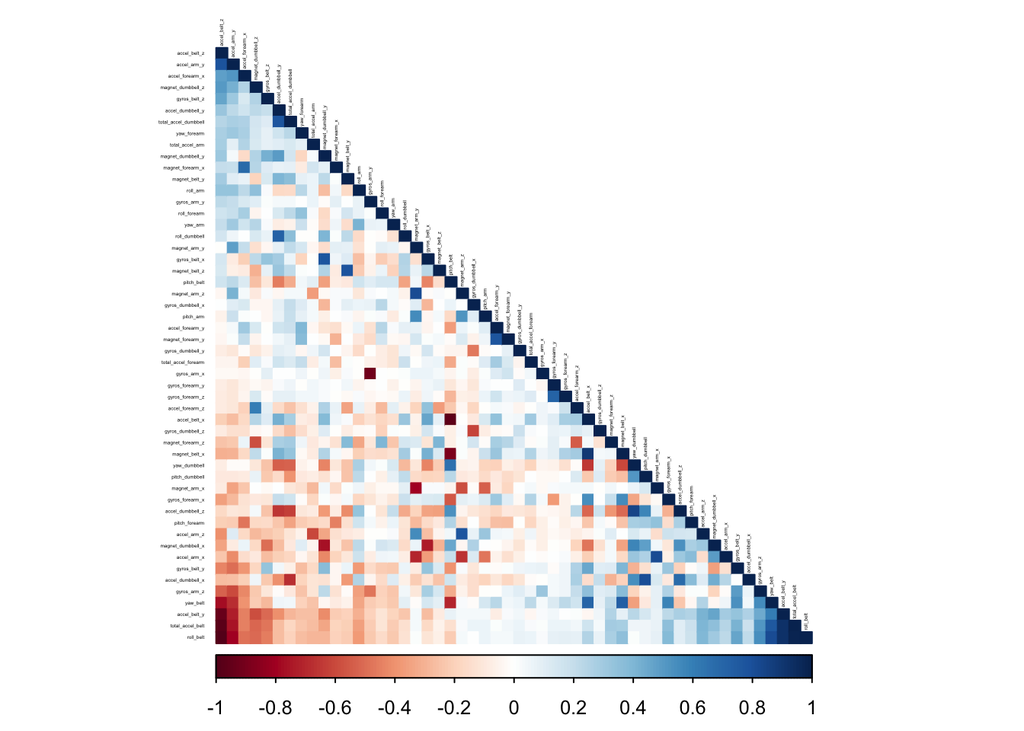

```r
corMatrix <- cor(myTraining[, -53])
library(corrplot)
corrplot(corMatrix, order = "FPC", method = "color", type = "lower",
         tl.cex = 0.2, tl.col = rgb(0, 0, 0))
```

The highly correlated variables are shown in darker colors in the plot above. Usually a PCA (Principal Components Analysis) is conducted as a pre-processing steps when the correlations among the variables are high.  
This step is skipped in this assignment cause there are new high correlations.

## Different Models

Two different machine learning algoritms are choosen to run the mulations, which are Random Forest and Decision Trees.

## Method 1 Random Forest

```r
set.seed(1234)
library(randomForest)
modFit1 <- randomForest(classe ~ ., data=myTraining)
prediction1 <- predict(modFit1, myTesting, type = "class")
rf <- confusionMatrix(prediction1, myTesting$classe)
rf
```

```
## Confusion Matrix and Statistics
##
##           Reference
## Prediction    A    B    C    D    E
##          A 1393    4    0    0    0
##          B    1  945    2    0    0
##          C    0    0  850    7    0
##          D    0    0    3  797    0
##          E    1    0    0    0  901
##
## Overall Statistics
##
##                Accuracy : 0.9963
##                  95% CI : (0.9942, 0.9978)
##     No Information Rate : 0.2845
##     P-Value [Acc > NIR] : < 2.2e-16
##
##                   Kappa : 0.9954
##  Mcnemar's Test P-Value : NA
##
## Statistics by Class:
##
##                      Class: A Class: B Class: C Class: D Class: E
## Sensitivity            0.9986   0.9958   0.9942   0.9913   1.0000
## Specificity            0.9989   0.9992   0.9983   0.9993   0.9998
## Pos Pred Value         0.9971   0.9968   0.9918   0.9963   0.9989
## Neg Pred Value         0.9994   0.9990   0.9988   0.9983   1.0000
## Prevalence             0.2845   0.1935   0.1743   0.1639   0.1837
## Detection Rate         0.2841   0.1927   0.1733   0.1625   0.1837
## Detection Prevalence   0.2849   0.1933   0.1748   0.1631   0.1839
## Balanced Accuracy      0.9987   0.9975   0.9962   0.9953   0.9999
```

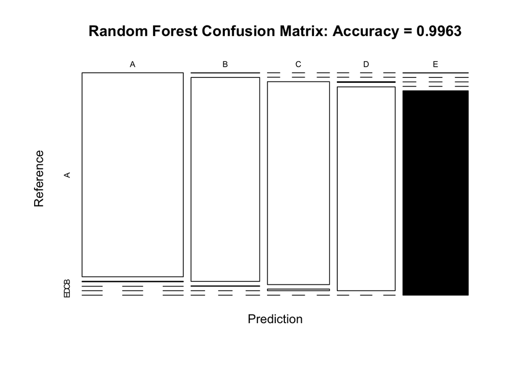

```r
plot(rf$table, col = rf$byClass, main = paste("Random Forest Confusion Matrix: Accuracy =", round(rf$overall['Accuracy'], 4)))
```

## Method 2 Decision Tree

```r
set.seed(1234)
library(rpart)
library(rpart.plot)
modFit2 <- rpart(classe ~ ., data=myTraining, method="class")
predictions1 <- predict(modFit2, myTesting, type = "class")
dctree <- confusionMatrix(predictions1, myTesting$classe)
dctree
```

```
## Confusion Matrix and Statistics
##
##           Reference
## Prediction    A    B    C    D    E
##          A 1286  210   19   75   44
##          B   42  555   73   33   58
##          C   33   71  692  115   94
##          D   17   72   45  511   55
##          E   17   41   26   70  650
##
## Overall Statistics
##
##                Accuracy : 0.7533
##                  95% CI : (0.7409, 0.7653)
##     No Information Rate : 0.2845
##     P-Value [Acc > NIR] : < 2.2e-16
##
##                   Kappa : 0.6861
##  Mcnemar's Test P-Value : < 2.2e-16
##
## Statistics by Class:
##
##                      Class: A Class: B Class: C Class: D Class: E
## Sensitivity            0.9219   0.5848   0.8094   0.6356   0.7214
## Specificity            0.9008   0.9479   0.9227   0.9539   0.9615
## Pos Pred Value         0.7870   0.7293   0.6886   0.7300   0.8085
## Neg Pred Value         0.9667   0.9049   0.9582   0.9303   0.9388
## Prevalence             0.2845   0.1935   0.1743   0.1639   0.1837
## Detection Rate         0.2622   0.1132   0.1411   0.1042   0.1325
## Detection Prevalence   0.3332   0.1552   0.2049   0.1427   0.1639
## Balanced Accuracy      0.9113   0.7664   0.8660   0.7947   0.8415
```

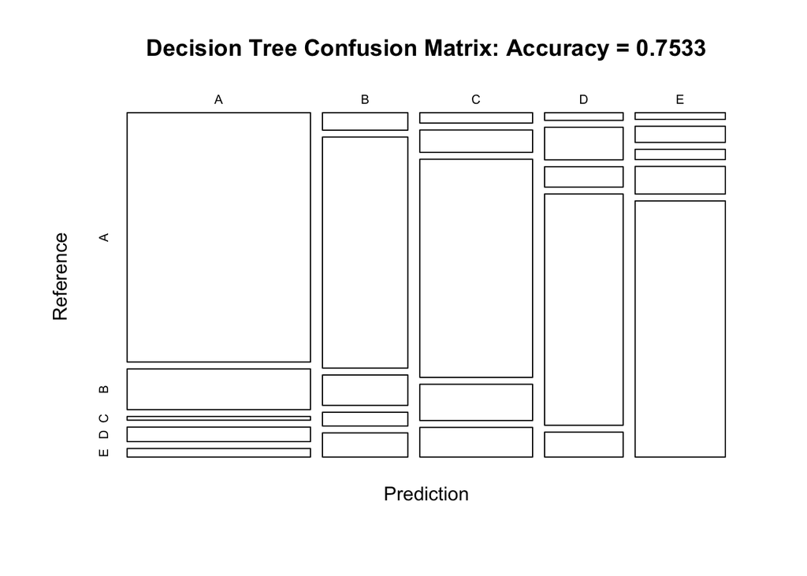

```r
plot(dctree$table, col =dctree$byClass, main = paste("Decision Tree Confusion Matrix: Accuracy =", round(dctree$overall['Accuracy'], 4)))
```

The above comparsion shows that random forest did a better job in prediting the results than decision tree,with higher accuracy, therefore, it is choosen to predit on the test data.

## Predicting on the Test Data

```r
prediction_test <- predict(modFit1,finalTesting, type = "class")
prediction_test
```

```
##  1  2  3  4  5  6  7  8  9 10 11 12 13 14 15 16 17 18 19 20
##  B  A  B  A  A  E  D  B  A  A  B  C  B  A  E  E  A  B  B  B
## Levels: A B C D E
```